# 2D Visualizations

In PyPMT we can make a variety of visualizations over the outlines of Antarctica or Greenland. If we want to create the map of Antarctica we can do the following:

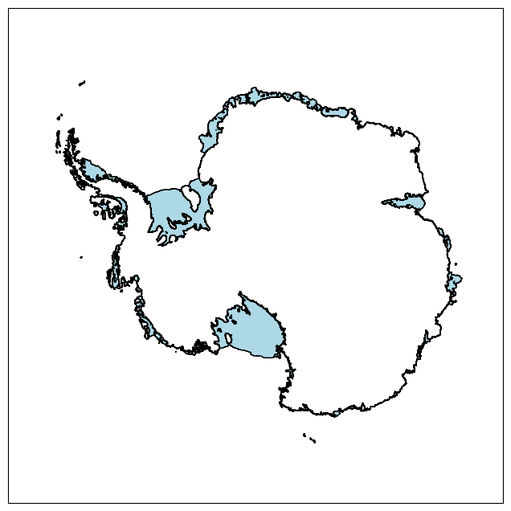

```python
# Create the map and axes using ant_bounds function
ax = PyPMT.ant_bounds()
```

Or conversely, we can get the outline of Greenland like so:

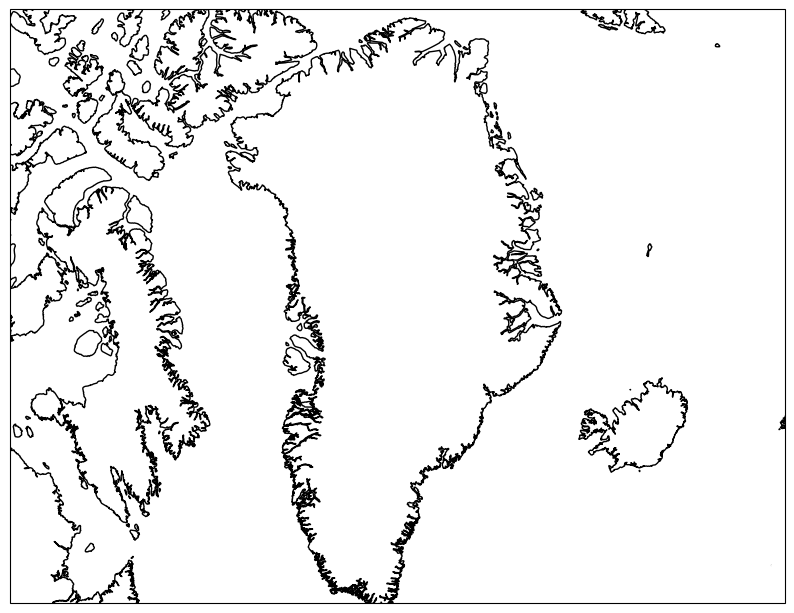

```python
ax = PyPMT.greenland_bounds()
```

And we can put a variety of visualizations on top of these maps. For example, if we wanted to plot a circle, make a geographic quadrangle, or label Antarctic landmarks, we can do the following:

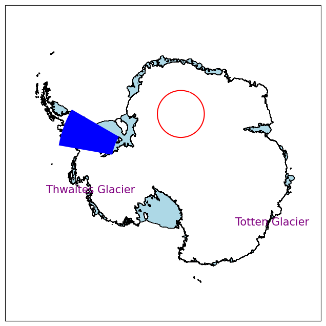

```python
# Create the map and axes using ant_bounds function
ax = PyPMT.ant_bounds()

# Draw a circle with a specified center lat/lon and radius
PyPMT.circle_ps(ax, lons = 20, lats = -80, radii = 500, km=True, color='r')

# label Antarctic landmarks
PyPMT.scar_label(ax, ['Totten Glacier', 'Thwaites Glacier'], color = 'purple', fontsize = 15)

# Draw a quadrangle with geoquadps
latlim = [-80, -70]
lonlim = [-80, -60]
PyPMT.geoquad_ps(ax, latlim, lonlim, color='b', linewidth=2)

# Show the plot
plt.show()
```

Or suppose we want to plot a line between two landmarks. In this example, we get the latitude and longitude for Thwaites Glacier by using the scar_loc function, and then use plot_ps to plot a line between these coordinates and the coordinates of the South Pole.

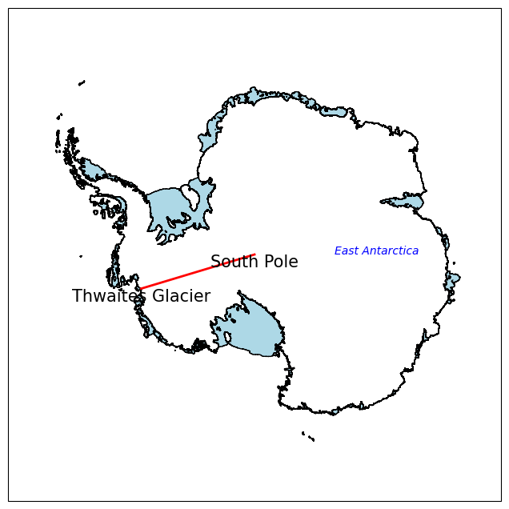

```python
# Get the coordinates for Thwaites Glacier
[mcmlat, mcmlon] = PyPMT.scar_loc('thwaites glacier')

# Create the map
ax = PyPMT.ant_bounds()

# Label the South Pole and Thwaites Glacier using scar_label
PyPMT.scar_label(ax, 'South Pole', fontsize = 15)
PyPMT.scar_label(ax, 'Thwaites Glacier', fontsize = 15)

# Draw a line between the coordinates for the South Pole and Thwaites Glacier
PyPMT.plot_ps(ax, [-90, mcmlat], [0, mcmlon], color = 'red', linewidth = 2)

# Place text to label East Antarctica
PyPMT.text_ps(-75, 90, 'East Antarctica', fontstyle='italic', color='blue')

# Show the plot
plt.show()
```

What if we wanted to plot points over a map? We can do so using scatter_ps... oh did we forget to mention that all these functions work for Greenland too?

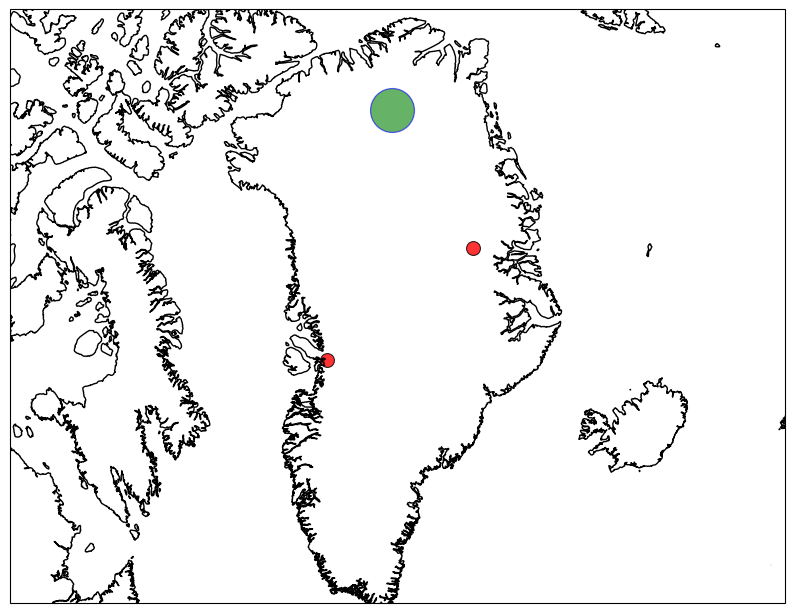

```python
ax = PyPMT.greenland_bounds()
# lets get some lat/lon pairs over Greenland
lat = [70, 74]
lon = [-50, -30]

# Plot the points on the map. The s parameter controls the size of a point.
PyPMT.scatter_ps(ax, lat, lon, s=100, c='r', alpha=0.8, edgecolors='k', linewidths=0.8) # plot multiple points at once
PyPMT.scatter_ps(ax, 80, -40, s=1000, c='g', alpha = 0.6, edgecolors = 'b', linewidths = 0.9) # or just one if we want
plt.show()
```

PyPMT offers many options for visualizations, like these cool contour plots! First, lets load in some bedmachine data to generate the plot with.

Suppose we have used xarray to open a BedMachine dataset pertaining to Antarctica, and we name our dataset 'ds'.

```
<cartopy.mpl.contour.GeoContourSet at 0x1c2980e8d50>
```

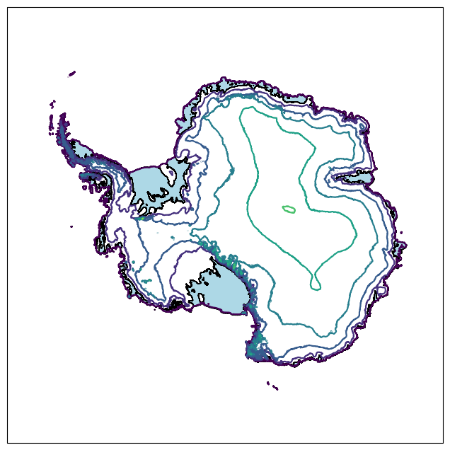

```python
ax = PyPMT.ant_bounds()
PyPMT.contour_ps(ds['x'].values, ds['y'].values, ds['surface'].values, ax = ax)
```

We can also make a contour plot with fill:

```
<cartopy.mpl.contour.GeoContourSet at 0x201561f45b0>
```

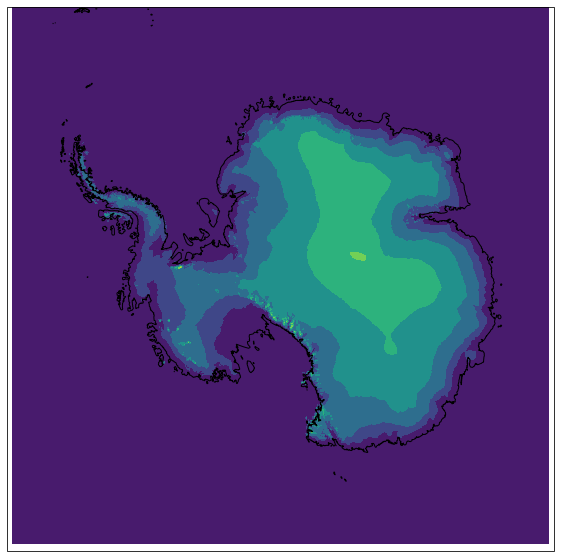

```python
ax = PyPMT.ant_bounds()
PyPMT.contour_ps(ds['x'].values, ds['y'].values, ds['surface'].values, ax = ax, fill = True)
```

We can also generate a psuedocolor plot of our data. Once again, we are using bedmachine data.

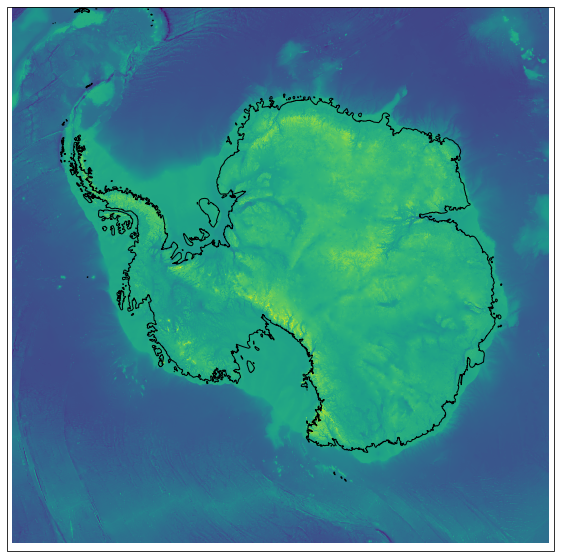

```python
ax = PyPMT.ant_bounds()
PyPMT.pcolor_ps(ax, ds['x'].values, ds['y'].values, ds['bed'].values)
plt.show()
```